# My Two-way ANOVA: Daily Steps, Soda, and Gender

```r
# Load necessary libraries
library(mosaic)
library(DT)
library(pander)
library(car)
library(tidyverse)


steps_data <- read_csv("data.csv")


steps_data <- steps_data %>%
  mutate(
    Soda_Group = as.factor(Soda_Group),
    Gender = as.factor(Gender)
  )
```

## Introduction

**Overall Research Question:** How do 0-calorie soda consumption and gender interact to affect a person’s average daily steps? Are there significant main effects for either soda consumption or gender on daily steps?

**Analysis:** A two-way ANOVA will be conducted to analyze the data.

- **Dependent Variable (Quantitative):** `Daily_Steps`
- **Independent Variable 1 (Categorical):** `Soda_Group` (Levels: “Drinks 0-Calorie Soda”, “Does Not Drink Soda”)
- **Independent Variable 2 (Categorical):** `Gender` (Levels: “Male”, “Female”)

We will test for a significant interaction effect (`Soda_Group * Gender`) first. If the interaction is not significant, we will examine the main effects of each factor.

## Research Questions & Hypotheses

**Significance Level:** $\alpha = 0.05$

### 1. Interaction Effect

**Research Question:** Is there an interaction between soda consumption and gender on daily steps?

- **Null Hypothesis ($H_0$):** There is no interaction effect between `Soda_Group` and `Gender` on `Daily_Steps`. ($\alpha = 0.05$)
- **Alternative Hypothesis ($H_a$):** There is a significant interaction effect between `Soda_Group` and `Gender` on `Daily_Steps`.

### 2. Main Effect of Soda Consumption

**Research Question:** Does soda consumption affect daily steps?

- **Null Hypothesis ($H_0$):** There is no main effect of `Soda_Group` on `Daily_Steps`. ($\alpha = 0.05$)
- **Alternative Hypothesis ($H_a$):** There is a significant main effect of `Soda_Group` on `Daily_Steps`.

### 3. Main Effect of Gender

**Research Question:** Does gender affect daily steps?

- **Null Hypothesis ($H_0$):** There is no main effect of `Gender` on `Daily_Steps`. ($\alpha = 0.05$)
- **Alternative Hypothesis ($H_a$):** There is a significant main effect of `Gender` on `Daily_Steps`.

## Descriptive Statistics

First, let’s look at the raw data and get summary statistics for our four groups.

```r
datatable(steps_data, options = list(pageLength = 5))
```

|  | Soda_Group | Gender | Daily_Steps |
| --- | --- | --- | --- |
| 1 | Drinks 0-Calorie Soda | Male | 7096 |
| 2 | Drinks 0-Calorie Soda | Male | 6461 |
| 3 | Drinks 0-Calorie Soda | Male | 7247 |
| 4 | Drinks 0-Calorie Soda | Male | 8123 |
| 5 | Drinks 0-Calorie Soda | Male | 6365 |
| 6 | Drinks 0-Calorie Soda | Male | 6365 |
| 7 | Drinks 0-Calorie Soda | Male | 8179 |
| 8 | Drinks 0-Calorie Soda | Male | 7367 |
| 9 | Drinks 0-Calorie Soda | Male | 6130 |
| 10 | Drinks 0-Calorie Soda | Male | 7142 |

[output cut: 110 more lines]

```r
favstats(Daily_Steps ~ Soda_Group + Gender, data = steps_data) %>%
  pander(caption = "Descriptive Statistics for Daily Steps by Group")
```

Descriptive Statistics for Daily Steps by Group (continued below)

| Soda_Group.Gender | min | Q1 | median | Q3 | max | mean |
| --- | --- | --- | --- | --- | --- | --- |
| Does Not Drink Soda.Female | 5481 | 7020 | 7369 | 7687 | 9863 | 7379 |
| Drinks 0-Calorie Soda.Female | 3580 | 5685 | 6226 | 6937 | 7764 | 6212 |
| Does Not Drink Soda.Male | 5840 | 7091 | 7735 | 8344 | 9652 | 7678 |
| Drinks 0-Calorie Soda.Male | 4686 | 6008 | 6365 | 6960 | 8179 | 6411 |

| sd | n | missing |
| --- | --- | --- |
| 908.9 | 30 | 0 |
| 992 | 30 | 0 |
| 931.1 | 30 | 0 |
| 900 | 30 | 0 |

## Two-Way ANOVA Analysis

Since the assumptions are met, we can proceed with the two-way ANOVA. We use the `Anova()` function (with a capital “A”) from the `car` package, as it handles unbalanced designs correctly.

```r
steps_aov <- aov(Daily_Steps ~ Soda_Group * Gender, data = steps_data)



anova_results <- Anova(steps_aov, type = "III")
pander(anova_results, caption = "Two-Way ANOVA Results (Type III Sum of Squares)")
```

Two-Way ANOVA Results (Type III Sum of Squares)

|  | Sum Sq | Df | F value | Pr(>F) |
| --- | --- | --- | --- | --- |
| **(Intercept)** | 1.634e+09 | 1 | 1874 | 1.939e-73 |
| **Soda_Group** | 20426001 | 1 | 23.43 | 4.029e-06 |
| **Gender** | 1341314 | 1 | 1.539 | 0.2173 |
| **Soda_Group:Gender** | 75100 | 1 | 0.08615 | 0.7697 |
| **Residuals** | 101124075 | 116 | NA | NA |

## Checking ANOVA Assumptions

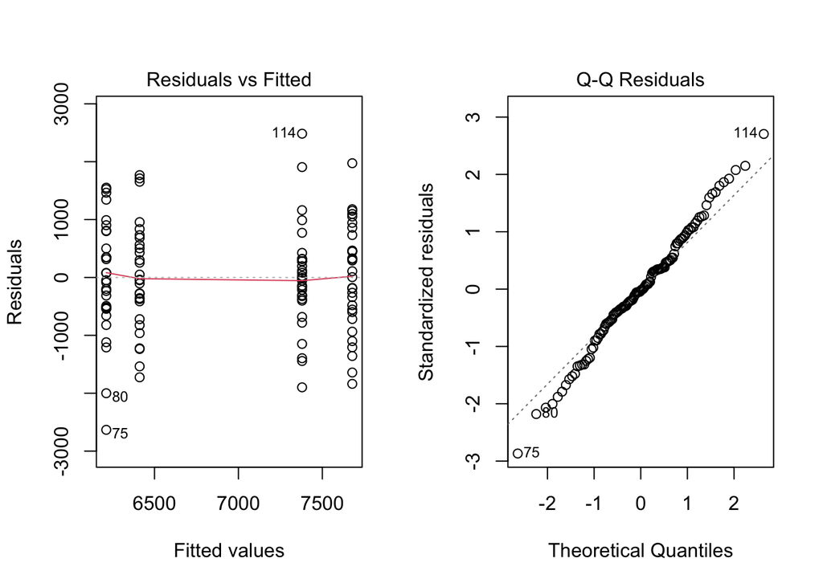

```r
par(mfrow=c(1,2))

plot(steps_aov, which=1)

plot(steps_aov, which=2)
```

```r
par(mfrow=c(1,1))
```

**Interpretation:**

- **Residuals vs Fitted (Left):** We are looking for a random scatter of points (“starry night”) around the red line. There is no obvious “megaphone” shape, so the assumption of equal variances is met.
- **Normal Q-Q (Right):** The points fall roughly along the diagonal dotted line. This indicates the residuals are normally distributed.

## Graphical Summaries & Conclusions

The ANOVA analysis found a significant effect for **Soda Consumption** (p < 0.001), but no significant effect for **Gender** (p = 0.217) and no significant **Interaction** (p = 0.770).

Below, we visualize these three specific findings.

### 1. Soda Consumption (Significant)

Since the p-value is significant (< 0.05), we color this graph to highlight the difference. Individuals who do not drink soda take significantly more steps.

**Numerical Summary for Soda Group:**

```r
# Calculate summary statistics by Soda Group
soda_summary <- steps_data %>%
  group_by(Soda_Group) %>%
  summarise(
    `Mean Daily Steps` = round(mean(Daily_Steps), 0),
    `Standard Deviation` = round(sd(Daily_Steps), 0),
    n = n()
  )
pander(soda_summary, caption = "Summary Statistics by Soda Consumption")
```

Summary Statistics by Soda Consumption

| Soda_Group | Mean Daily Steps | Standard Deviation | n |
| --- | --- | --- | --- |
| Does Not Drink Soda | 7529 | 925 | 60 |
| Drinks 0-Calorie Soda | 6312 | 944 | 60 |

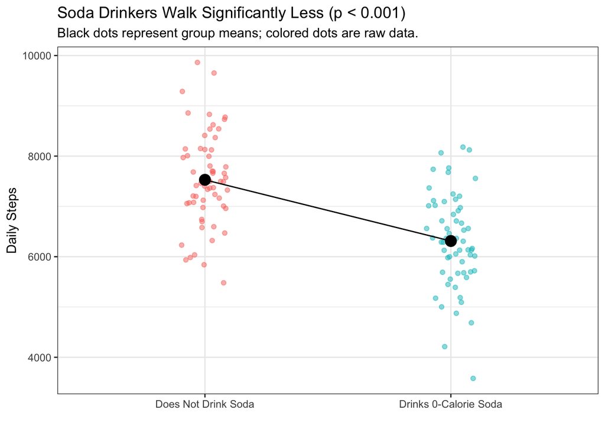

```r
ggplot(steps_data, aes(x = Soda_Group, y = Daily_Steps, color = Soda_Group)) +
  geom_jitter(width = 0.1, alpha = 0.5) +
  stat_summary(fun = mean, geom = "point", size = 4, color = "black") +
  stat_summary(fun = mean, geom = "line", aes(group=1), color = "black") +
  labs(
    title = "Soda Drinkers Walk Significantly Less (p < 0.001)",
    subtitle = "Black dots represent group means; colored dots are raw data.",
    y = "Daily Steps",
    x = ""
  ) +
  theme_bw() +
  theme(legend.position = "none")
```

### 2. Gender Effect (Not Significant)

**Numerical Summary for Gender:**

```r
# Calculate summary statistics by Gender
gender_summary <- steps_data %>%
  group_by(Gender) %>%
  summarise(
    `Mean Daily Steps` = round(mean(Daily_Steps), 0),
    `Standard Deviation` = round(sd(Daily_Steps), 0),
    n = n()
  )
pander(gender_summary, caption = "Summary Statistics by Gender")
```

Summary Statistics by Gender

| Gender | Mean Daily Steps | Standard Deviation | n |
| --- | --- | --- | --- |
| Female | 6796 | 1112 | 60 |
| Male | 7045 | 1110 | 60 |

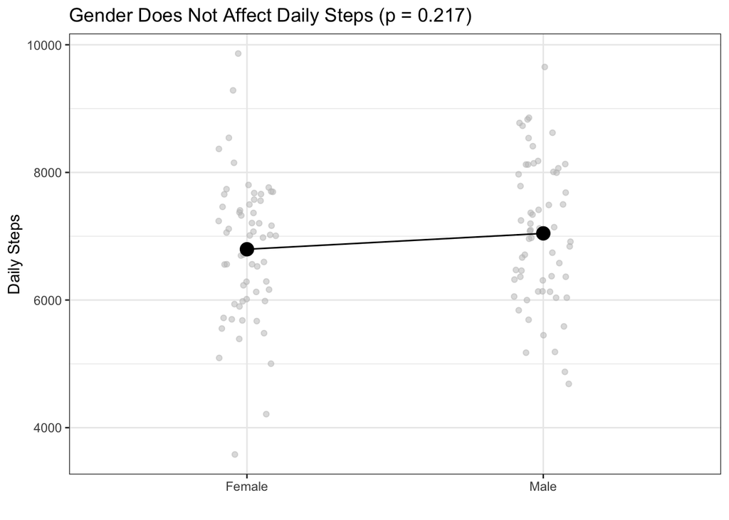

```r
ggplot(steps_data, aes(x = Gender, y = Daily_Steps)) +
  geom_jitter(width = 0.1, alpha = 0.5, color = "gray") +
  stat_summary(fun = mean, geom = "point", size = 4, color = "black") +
  stat_summary(fun = mean, geom = "line", aes(group=1), color = "black") +
  labs(
    title = "Gender Does Not Affect Daily Steps (p = 0.217)",
    y = "Daily Steps",
    x = ""
  ) +
  theme_bw()
```

### 3. Interaction Effect (Not Significant)

**Full Group Means (All Combinations):**

```r
# Calculate summary statistics by Soda Group and Gender
interaction_summary <- steps_data %>%
  group_by(Soda_Group, Gender) %>%
  summarise(
    `Mean Daily Steps` = round(mean(Daily_Steps), 0),
    `Standard Deviation` = round(sd(Daily_Steps), 0),
    n = n(),
    .groups = "drop"
  )
pander(interaction_summary, caption = "Summary Statistics by Soda Group and Gender")
```

Summary Statistics by Soda Group and Gender

| Soda_Group | Gender | Mean Daily Steps | Standard Deviation | n |
| --- | --- | --- | --- | --- |
| Does Not Drink Soda | Female | 7379 | 909 | 30 |
| Does Not Drink Soda | Male | 7678 | 931 | 30 |
| Drinks 0-Calorie Soda | Female | 6212 | 992 | 30 |
| Drinks 0-Calorie Soda | Male | 6411 | 900 | 30 |

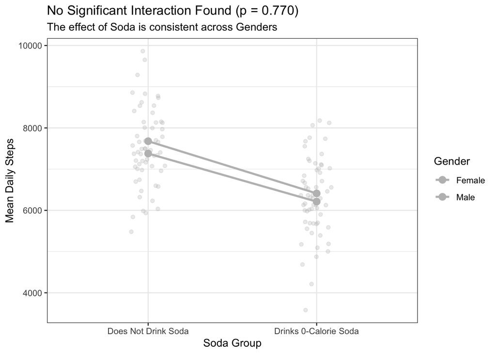

```r
ggplot(steps_data, aes(x = Soda_Group, y = Daily_Steps, color = Gender, group = Gender)) +
  geom_jitter(width = 0.1, alpha = 0.3) +
  stat_summary(fun = mean, geom = "point", size = 3) +
  stat_summary(fun = mean, geom = "line", linewidth = 1) +
  labs(
    title = "No Significant Interaction Found (p = 0.770)",
    subtitle = "The effect of Soda is consistent across Genders",
    y = "Mean Daily Steps",
    x = "Soda Group"
  ) +
  theme_bw() +
  scale_color_manual(values = c("gray", "gray"))
```

## Final Thoughts

The analysis indicates that **soda consumption** is the only significant factor affecting activity levels in this dataset.

- **Soda:** We observed a significant difference ($p < 0.001$) between the groups. Specifically, individuals who **do not drink soda** averaged approximately **7,528 steps per day**, which is significantly higher than the approximately **6,311 steps** averaged by those who drink 0-calorie soda.
- **Gender:** While males (mean ≈ 7,044 steps) had a slightly higher step count than females (mean ≈ 6,795 steps), this difference was **not statistically significant** ($p = 0.217$).
- **Interaction:** The lack of a significant interaction ($p = 0.770$) confirms that the negative association between soda consumption and step counts remains consistent for both genders.

**Recommendation:** If the goal is to associate behaviors with higher daily activity levels, “Not Drinking Soda” is associated with higher step counts (approximately **1,217 more steps per day** on average), regardless of gender.